# Data Engineering Case Study

## Step 2: data cleaning

Previously we have downloaded BTCUSDT minute-level OHLCV data from binance.us using their API and saved to our sql database in Postgres. In this section I would like to go through some steps to analyze any discrepancies in the data.

```python
import os
os.getcwd()
```

```
'C:\\Users\\micke\\OneDrive\\桌面\\Peerstreet Interview'
```

```python
import datetime
import pandas as pd
import psycopg2
import sqlalchemy
import seaborn as sns
import numpy as np
import config
import matplotlib.pyplot as plt
```

```python
class btcusdt_cleaner:

    def __init__(self,table_name,connection_params):
        self.table_name = table_name
        self.connection_params = connection_params
        self.df = None
        self.ts = None
        return

    def get_data(self):
        engine = sqlalchemy.create_engine(
            'postgresql://{user}:{password}@localhost:5432/{dbname}'.format(**self.connection_params)
         )
        self.df = pd.read_sql_table(
            self.table_name,
            con=engine)
        return


    def get_ts(self):
        '''
        Extract minute-level time series data from dataframe. "Merge" open and close price.

        Output saved in self.ts

        Returns
        -------
        None.
        '''
        df = self.df
        close_px = df["close"]
        close_px.index = pd.to_datetime(df["close_time"],unit="ms").round("1min")
        close_px = close_px[~close_px.index.duplicated(keep='first')]

        open_px  = df["open"]
        open_px.index = pd.to_datetime(df["open_time"],unit="ms").round("1min")
        open_px = open_px[~open_px.index.duplicated(keep='first')]

        open_px = open_px.reindex(pd.date_range(open_px.index[0],close_px.index[-1],freq="1min"))
        close_px = close_px.reindex(pd.date_range(open_px.index[0],close_px.index[-1],freq="1min"))

        open_px[open_px.isna()] = close_px
        self.ts = open_px.to_frame()
        self.ts = self.ts.rename(columns={"open":"px"})
        return
```

```python
pwd = config.pwd
connection_params = {
    "dbname" : "postgres",
    "user" : "postgres",
    "password" : pwd
    }
table_name = "klines"

cleaner = btcusdt_cleaner(table_name,connection_params)
cleaner.get_data()
cleaner.get_ts()
```

```python
pd.options.display.float_format = '{:.2f}'.format
df = cleaner.df
ts = cleaner.ts
```

```python
df.head()
```

|  | open_time | open | high | low | close | volume | close_time | quote_asset_volume | number_of_trades | taker_buy_base_asset_volume | taker_buy_quote_asset_volume |
| --- | --- | --- | --- | --- | --- | --- | --- | --- | --- | --- | --- |
| 0 | 1502942400000.00 | 4261.48 | 4261.48 | 4261.48 | 4261.48 | 1.78 | 1502942459999.00 | 7564.91 | 3.00 | 0.08 | 320.39 |
| 1 | 1502942460000.00 | 4261.48 | 4261.48 | 4261.48 | 4261.48 | 0.00 | 1502942519999.00 | 0.00 | 0.00 | 0.00 | 0.00 |
| 2 | 1502942520000.00 | 4280.56 | 4280.56 | 4280.56 | 4280.56 | 0.26 | 1502942579999.00 | 1117.54 | 2.00 | 0.26 | 1117.54 |
| 3 | 1502942580000.00 | 4261.48 | 4261.48 | 4261.48 | 4261.48 | 0.01 | 1502942639999.00 | 51.17 | 3.00 | 0.01 | 51.17 |
| 4 | 1502942640000.00 | 4261.48 | 4261.48 | 4261.48 | 4261.48 | 0.14 | 1502942699999.00 | 600.00 | 1.00 | 0.14 | 600.00 |

```python
ts.head()
```

|  | px |
| --- | --- |
| 2017-08-17 04:00:00 | 4261.48 |
| 2017-08-17 04:01:00 | 4261.48 |
| 2017-08-17 04:02:00 | 4280.56 |
| 2017-08-17 04:03:00 | 4261.48 |
| 2017-08-17 04:04:00 | 4261.48 |

### Check 1: Bad time interval

```python
sum(df["open_time"].duplicated())  # no duplicate open time
```

```
0
```

```python
sum(df["close_time"].duplicated())  # no duplicate close time
```

```
0
```

```python
df[(df["close_time"] - df["open_time"]) < 0]  # close_time before open - bad data point - decision: drop
```

|  | open_time | open | high | low | close | volume | close_time | quote_asset_volume | number_of_trades | taker_buy_base_asset_volume | taker_buy_quote_asset_volume |
| --- | --- | --- | --- | --- | --- | --- | --- | --- | --- | --- | --- |
| 1753091 | 1608559740000.00 | 22646.53 | 22646.53 | 22646.53 | 22646.53 | 0.00 | 1608558440521.00 | 0.00 | 0.00 | 0.00 | 0.00 |

```python
df[(df["open_time"] - df["close_time"].shift(1)) <= 0.000000001]  # no overlapping intervals
```

|  | open_time | open | high | low | close | volume | close_time | quote_asset_volume | number_of_trades | taker_buy_base_asset_volume | taker_buy_quote_asset_volume |
| --- | --- | --- | --- | --- | --- | --- | --- | --- | --- | --- | --- |

```python
df[(df["close_time"] - df["open_time"])!=59999]  # inconsistent length of interval - decision: merge close and open into one ts and keep
```

|  | open_time | open | high | low | close | volume | close_time | quote_asset_volume | number_of_trades | taker_buy_base_asset_volume | taker_buy_quote_asset_volume |
| --- | --- | --- | --- | --- | --- | --- | --- | --- | --- | --- | --- |
| 29519 | 1504713540000.00 | 4603.74 | 4619.43 | 4603.74 | 4619.43 | 0.28 | 1504713600000.00 | 1277.14 | 2.00 | 0.02 | 108.54 |
| 156660 | 1512367200000.00 | 11476.87 | 11478.00 | 11476.87 | 11478.00 | 0.29 | 1512367220798.00 | 3322.47 | 4.00 | 0.29 | 3322.47 |
| 177061 | 1513591220799.00 | 18668.53 | 18668.53 | 18657.24 | 18668.53 | 0.00 | 1513591242445.00 | 63.94 | 4.00 | 0.00 | 6.10 |
| 177197 | 1513600140000.00 | 19160.13 | 19180.00 | 19160.12 | 19161.00 | 2.01 | 1513600153419.00 | 38465.57 | 28.00 | 0.79 | 15130.70 |
| 201044 | 1515034800000.00 | 15110.90 | 15119.98 | 15110.90 | 15119.97 | 4.64 | 1515034814838.00 | 70055.81 | 34.00 | 1.45 | 21844.74 |
| 251167 | 1518049680000.00 | 7790.00 | 7794.91 | 7783.81 | 7784.02 | 8.15 | 1518049694788.00 | 63515.48 | 100.00 | 6.60 | 51454.17 |
| 252368 | 1518242354789.00 | 8855.03 | 8855.03 | 8841.72 | 8842.98 | 6.26 | 1518242399999.00 | 55351.56 | 106.00 | 1.82 | 16094.80 |
| 253674 | 1518321600000.00 | 7976.73 | 7988.21 | 7960.13 | 7976.74 | 7.72 | 1518321600999.00 | 61509.19 | 45.00 | 4.55 | 36250.92 |
| 458637 | 1530663720000.00 | 6485.97 | 6490.00 | 6477.67 | 6481.69 | 11.48 | 1530663745551.00 | 74421.26 | 51.00 | 9.70 | 62904.38 |
| 944561 | 1559941980000.00 | 7930.85 | 7930.85 | 7930.85 | 7930.85 | 0.00 | 1559941993524.00 | 0.00 | 0.00 | 0.00 | 0.00 |
| 1313199 | 1582112100000.00 | 10150.00 | 10150.00 | 10147.51 | 10148.93 | 2.71 | 1582112132286.00 | 27468.11 | 65.00 | 1.07 | 10812.95 |
| 1332871 | 1583313660000.00 | 8805.72 | 8806.78 | 8795.06 | 8795.06 | 0.80 | 1583313706694.00 | 7036.50 | 32.00 | 0.11 | 1010.12 |
| 1753091 | 1608559740000.00 | 22646.53 | 22646.53 | 22646.53 | 22646.53 | 0.00 | 1608558440521.00 | 0.00 | 0.00 | 0.00 | 0.00 |
| 1827052 | 1613014800000.00 | 44582.07 | 44582.07 | 44582.07 | 44582.07 | 0.00 | 1613014854773.00 | 0.00 | 0.00 | 0.00 | 0.00 |
| 1931873 | 1619323200000.00 | 49626.76 | 49705.04 | 49600.24 | 49683.94 | 5.89 | 1619323258146.00 | 292226.01 | 224.00 | 4.23 | 209956.01 |
| 2089868 | 1628819940000.00 | 44815.87 | 44847.27 | 44814.36 | 44847.26 | 5.59 | 1628819999000.00 | 250551.62 | 946.00 | 4.42 | 198288.47 |
| 2281178 | 1640321940000.00 | 50951.62 | 50951.62 | 50926.58 | 50951.47 | 16.24 | 1640321994362.00 | 827543.11 | 1124.00 | 6.84 | 348443.71 |

### Check 2: Outliers

Two checks for ouliers

1. Look at distribution (histogram) of log returns;
2. Look at price moving average and if prices "jump" out of their k-standard deviation bands.

```python
ohlc = df[['open', 'high', 'low', 'close']]
ohlc.index = pd.to_datetime(df["open_time"],unit="ms")
for col in ohlc.columns:
    logr = np.diff(np.log(ohlc[col]))
    logr = np.insert(logr,0,np.nan)
    ohlc["{col}_logr".format(col=col)] = logr
```

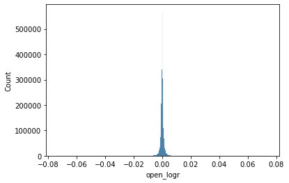

```python
sns.histplot(ohlc["open_logr"],bins=500,kde=False)
```

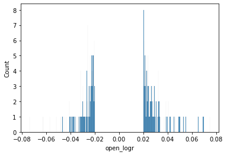

```python
sns.histplot(ohlc.loc[(ohlc["open_logr"]<-0.02) | (ohlc["open_logr"]>0.02),"open_logr"],bins=1000,kde=False)
```

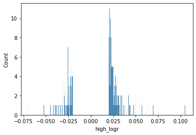

```python
sns.histplot(ohlc.loc[(ohlc["high_logr"]<-0.02) | (ohlc["high_logr"]>0.02),"high_logr"],bins=1000,kde=False)
```

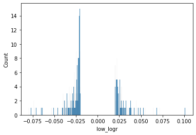

```python
sns.histplot(ohlc.loc[(ohlc["low_logr"]<-0.02) | (ohlc["low_logr"]>0.02),"low_logr"],bins=1000,kde=False)
```

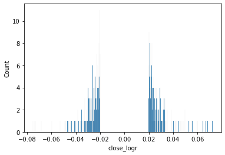

```python
sns.histplot(ohlc.loc[(ohlc["close_logr"]<-0.02) | (ohlc["close_logr"]>0.02),"close_logr"],bins=1000,kde=False)
```

Conclusion: safe to categorize log returns outside of [-0.02,0.02] are outliers. However, they appear to be real jumps instead of data errors.

We can also detect/visualize discontinuity with k-std moving average bands.

```python
k= k1 = k2 = 10
w1  = 60
w2 = 300

ts["ma{w1}".format(w1=w1)] = ts["px"].rolling(window=w1).mean()
ts["ub{w1}".format(w1=w1)] = ts["ma{w1}".format(w1=w1)] + ts["px"].rolling(window=w1).std() * k1
ts["lb{w1}".format(w1=w1)] = ts["ma{w1}".format(w1=w1)] - ts["px"].rolling(window=w1).std() * k1
ts["%ma{w1}".format(w1=w1)] = ts["px"] / ts["ma{w1}".format(w1=w1)]

ts["ma{w2}".format(w2=w2)] = ts["px"].rolling(window=w2).mean()
ts["ub{w2}".format(w2=w2)] = ts["ma{w2}".format(w2=w2)] + ts["px"].rolling(window=w2).std() * k2
ts["lb{w2}".format(w2=w2)] = ts["ma{w2}".format(w2=w2)] - ts["px"].rolling(window=w2).std() * k2
ts["%ma{w2}".format(w2=w2)] = ts["px"] / ts["ma{w2}".format(w2=w2)]
```

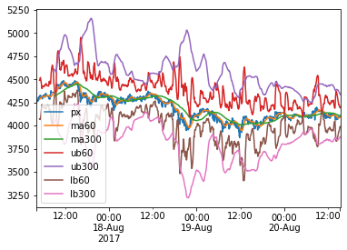

```python
ts[1:5000][["px","ma60","ma300","ub60","ub300","lb60","lb300"]].plot()
```

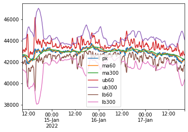

```python
ts[-5000:-1][["px","ma60","ma300","ub60","ub300","lb60","lb300"]].plot()
```

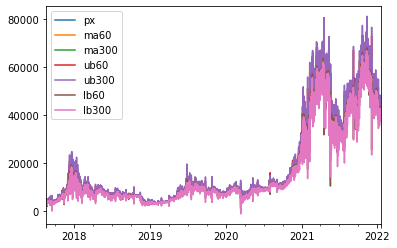

```python
ts[["px","ma60","ma300","ub60","ub300","lb60","lb300"]].plot()
```

The point-in-time prices that exceeed a 10 standard deviation moving average band would be labeled as a "discontinuity"/"jump".

```python
discontinuous = (ts["px"] > ts["ub{w1}".format(w1=w1)]) \
        | (ts["px"] > ts["ub{w2}".format(w2=w2)]) \
        | (ts["px"] < ts["lb{w1}".format(w1=w1)]) \
        | (ts["px"] < ts["lb{w2}".format(w2=w2)])
tmp = ts[discontinuous]
```

```python
sum(discontinuous)  # total potential discontinuities: 82
```

```
82
```

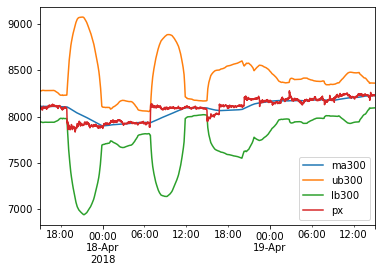

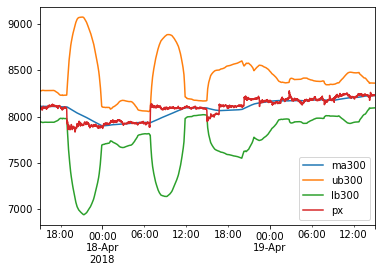

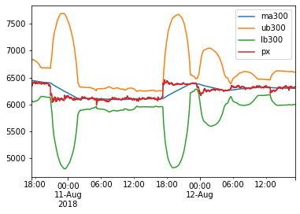

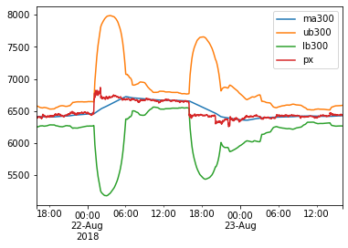

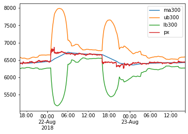

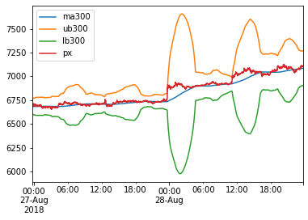

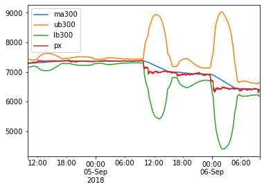

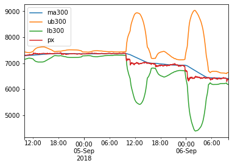

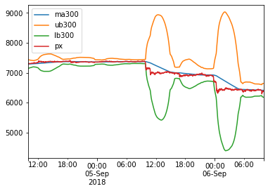

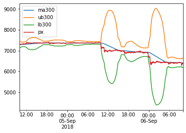

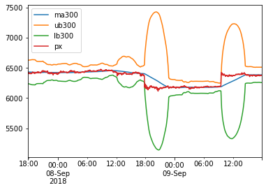

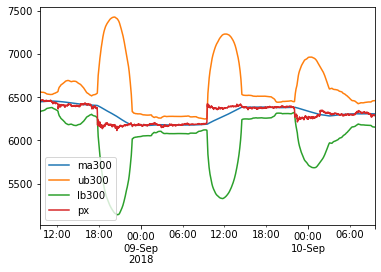

[70 more figures not shown]

```python
for i in range(tmp.shape[0]):
    ts.loc[(tmp.index[i]-pd.Timedelta(days=1)):(tmp.index[i]+pd.Timedelta(days=1)),
           ["ma300","ub300","lb300","px"]].plot()
```

Conclusion: the jumps are either sudden price movements following periods of very low volatility or "flash crashes". The recommended preprocessing depends on the business use. For prediction, many algorithms have loss functions that are sensitive to outliers, so we should "clip" the returns at these time points to say [-0.02,0.02]. For simulation, we want to model the frequency and maginitude of the "jumps", so we should keep them as raw values.

### Check 3: 0 volumn / stale OHLC

There are many klines with 0 volume in the interval.

```python
volume = df["volume"]
volume.index = pd.to_datetime(df["open_time"],unit="ms")
```

```python
sum(volume == 0)
```

```
23931
```

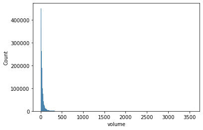

```python
sns.histplot(volume,bins=500)
```

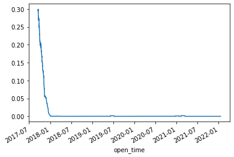

```python
# df["volume"].rolling(60*24*30).apply(lambda s:sum(s==0) / len(s)) bad code!

((volume<=0.00000001).rolling(60*24*30).sum() / (60*24*30)).plot()
```

we see that, although there are many 0-volume time intervals, those occur mostly before 2018, and therefore should not be data errors. The recommended preprocessing step is to keep.

### Conclusion

Putting everything together, I would recommend:

1. Negative interval length / overlapping time intervals - drop (status = 2);
2. Intervals of uneven width - keep, merge into one ts if there are > 1min gaps;
3. Jumps - use k-std bands around moving average to determine outliers - keep, and label (status = 3);
4. 0 volume, stale OHLC, repeated values - keep, but label as warning (status = 1);
5. Missing ts data by reindexing - keep, but label as potentially interpolated data (status = 4).